Ternary Plots:

Our Plot Designation

Full Plot Name

Plot Description

Primary Literature

Image

QFL

QFL Provenance Diagram

This plot shows the provenance of a rock, broken into the mineral endmembers Quartz, Feldspar, and Lithics

Dickinson, W. R., & Suczek, C. A. (1979). Plate tectonics and sandstone compositions. Aapg Bulletin, 63(12), 2164-2182.

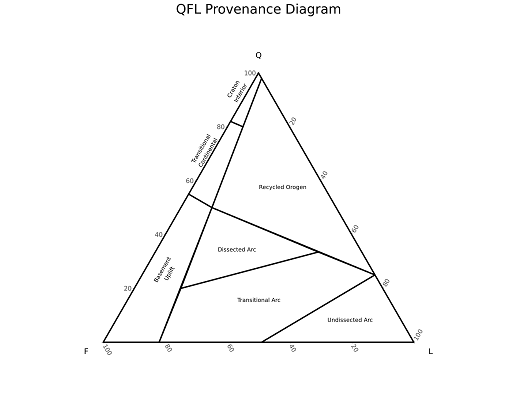

QFL2

QFL Classification Diagram

This plot shows the classification of a rock, broken into the mineral endmembers Quartz, Feldspar, and Lithics

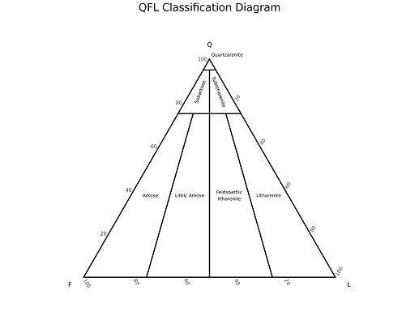

AFM

AFM Diagram

This plot shows the trends apparent in rocks formed in different environments, broken into the oxide endmembers Alkalis, Iron oxide, and Magnesium oxide

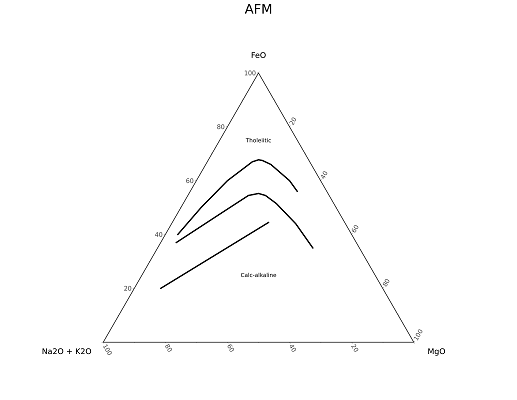

QAPi

QAP Diagram (Intrusive)

This plot shows the classification of an intrusive rock, broken into the mineral endmembers Quartz, Alkali feldspar, and Plagioclase

Streckeisen, A. (1976). To each plutonic rock its proper name. Earth-science reviews, 12(1), 1-33.

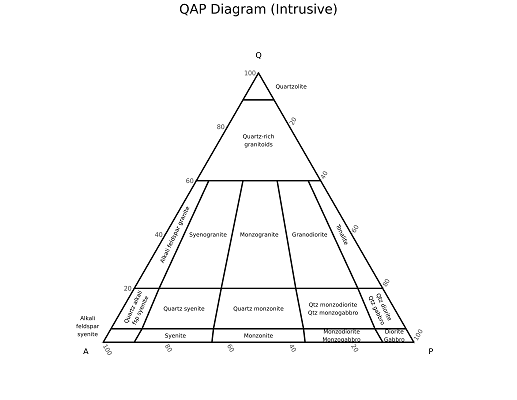

QAPe

QAP Diagram (Extrusive)

This plot shows the classification of an extrusive rock, broken into the mineral endmembers Quartz, Alkali feldspar, and Plagioclase

Streckeisen, A. (1980). Classification and nomenclature of volcanic rocks, lamprophyres, carbonatites and melilitic rocks IUGS Subcommission on the systematics of igneous rocks. Geologische Rundschau, 69(1), 194-207.

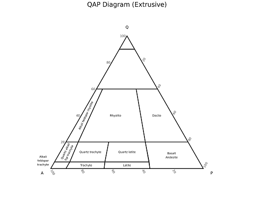

NFsp

Normative Quartz-rich Intrusive Igneous Rock Classification

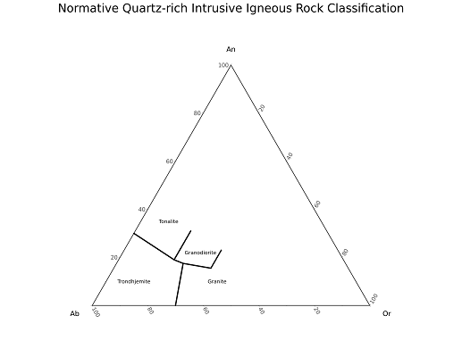

MFsp65

Modal Quartz-rich Intrusive Igneous Rock Classification

O’Connor, J. T. (1965). A classification for quartz-rich igneous rocks based on feldspar ratios. US Geological Survey Professional Paper B, 525, 79-84.

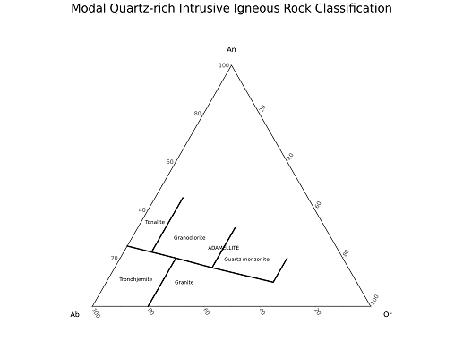

Nfsp65

Normative Quartz-rich Extrusive Igneous Rock Classification

O’Connor, J. T. (1965). A classification for quartz-rich igneous rocks based on feldspar ratios. US Geological Survey Professional Paper B, 525, 79-84.

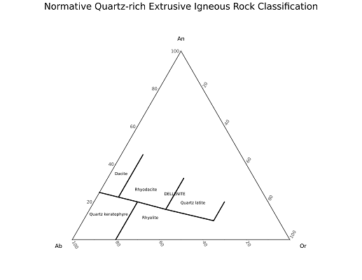

USDAsoils

USDA Textural Sediment Classification

This plot shows the sediment classification used by the United States Department of Agriculture

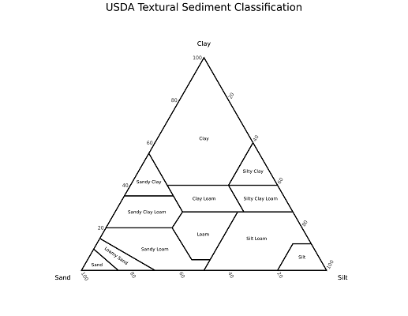

Shep

Shepard Sediment Classification

This plot shows Francis P. Shepard’s sediment classification, based on the ratios of sand, silt, and clay

Shepard, F.P. (1954). Nomenclature based on sand-silt-clay ratios. Journal of Sedimentary Petrology, 24, 151-158.

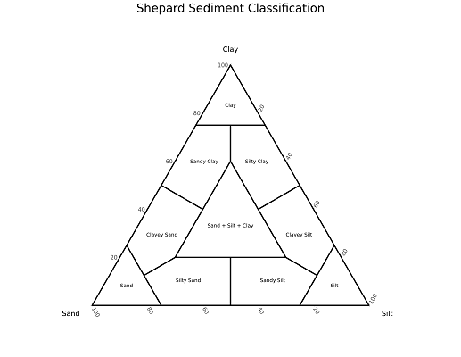

FspClass

Feldspar Classification Diagram

This plot shows the specific species determination of feldspar minerals, based on the mineral endmembers of Potassium feldspar, Sodium feldspar, and Calcium feldspar

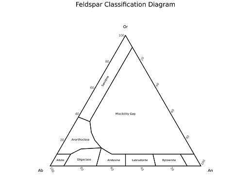

PeridClass

Peridotite Classification Diagram

This plot shows the classification of peridotite and pyroxenite rock types, based on the mineral endmembers of Olivine, Orthopyroxene, and Clinopyroxene

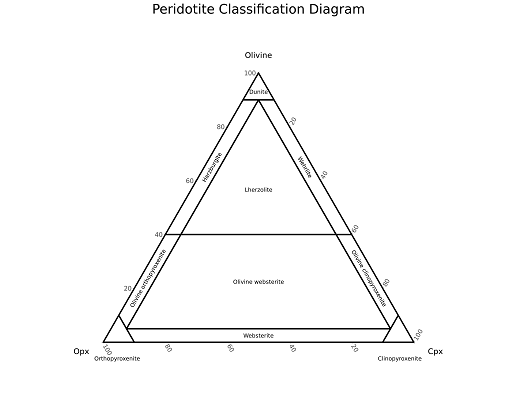

PyroxClass

Pyroxene Classification Diagram

This plot shows the classification of pyroxene mineral types, based on the pyroxene mineral endmembers of Wollastonite, Enstatite, and Ferrosilite

Morimoto, N., Fabries, J., Ferguson, A. K., Ginzburg, I. V., Ross, M., Seifert, F. A., Zussman, J., Aoki, K., & Gottardi, G. (1988). Nomenclature of pyroxenes. American Mineralogist, 73, 1123-1133.

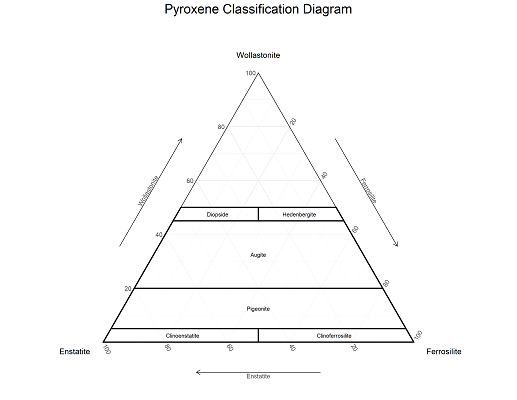

Folk

Folk Sediment Classification

This plot shows the 1954 Folk classification of sediments, with section boundaries based on 2:1 and 1:2 ratios of clay to silt and sand percentages of 90%, 50%, and 10%.

Folk, R. L. (1954). The distinction between grain size and mineral composition in sedimentary-rock nomenclature. The Journal of Geology, 62(4), 344-359.

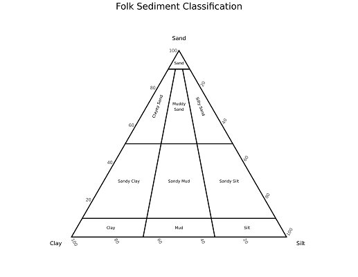

Bivariate Plots:

Our Plot Designation

Full Plot Name

Plot Description

Primary Literature

Image

TAS_classic

Classic Total Alkali vs Silica Plot

The plot shows the classic rendition of volcanic (extrusive) rock classifications based solely on the ratio of alkali oxide weight % and silica weight %

BAS, M. L., Maitre, R. L., Streckeisen, A., Zanettin, B., & IUGS Subcommission on the Systematics of Igneous Rocks. (1986). A chemical classification of volcanic rocks based on the total alkali-silica diagram. Journal of Petrology, 27(3), 745-750.

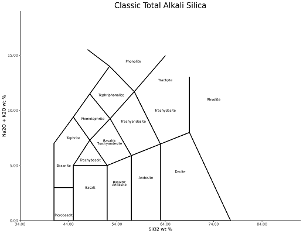

TAS_ext

Total Alkali vs Silica - Extrusive Plot

This plot shows extrusive rock classifications based solely on the ratio of alkali oxide weight % and silica weight %

Middlemost, E. (1994) Naming materials in the magma/igneous rock system. Earth-Science Reviews, 37, 215-224

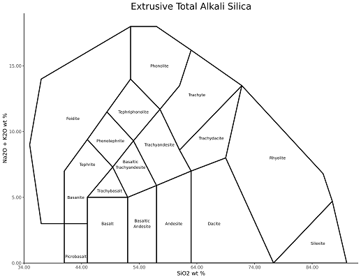

TAS_int

Total Alkali vs Silica - Intrusive Plot

This plot shows intrusive rock classifications based solely on the ratio of alkali oxide weight % and silica weight %

Middlemost, E. (1994) Naming materials in the magma/igneous rock system. Earth-Science Reviews, 37, 215-224

TAS_cox

Total Alkali vs Silica - Extrusive Plot

This plot shows non-potassic extrusive rock classifications of Cox, Bell, and Pankhurst, based solely on the ratio of alkali oxide weight % and silica weight %

Cox, K. G., Bell, J. D., & Pankhurst, R. J. (1979) The interpretation of igneous rocks. London, GB: Unwin Hyman Ltd.

TAS_wilson

Total Alkali vs Silica - Intrusive Plot

This plot shows intrusive rock classifications from Wilson, using the plot boundaries of Cox, Bell, and Pankhurst. Based on the ratio of alkali oxide weight % and silica weight %

Wilson, B.M. (2007) Igneous Petrogenesis: A global tectonic approach. Berlin, DE: Springer-Verlag.

PT-Meta Plots:

Our Plot Designation

Full Plot Name

Plot Description

Primary Literature

Image

PT

Pressure-Temperature Metamorphic Facies Diagram

This is a classic metamorphic facies diagram, adapted from Pentti Eskola’s 1920 publication

Eskola, P. (1920) The Mineral Facies of Rocks. Norsk. Geol. Tidsskr. 6, 143-194.

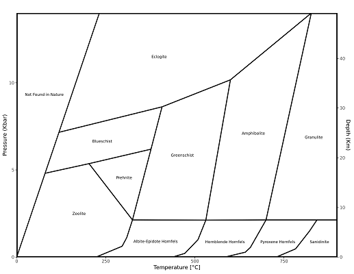

PT_peacock

Pressure-Temperature Metamorphic Facies Diagram

This is the metamorphic facies diagram used by Indiana University, which was adapted from Simon M. Peacock’s 1993 GSA bulletin

Peacock, S.M. (1993) The importance of blueschists - eclogite dehydration reactions in subducting oceanic crust. Geol. Soc. Amer. Bull, 105, 684-694.

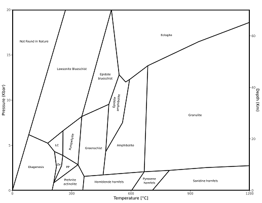

Aluminosilicates

Aluminosilicates phase diagram

This plot shows the mineral phase diagram of the aluminosilicate polymorphs: Sillimanite, Andalusite, and Kyanite

Aramaki, S., & Roy, R. (1962). Revised phase diagram for the system Al2O3SiO2. Journal of the American Ceramic Society, 45(5), 229-242.

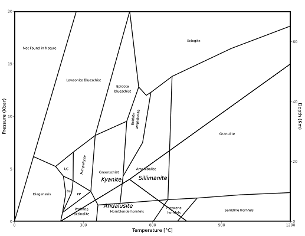

Intrusion Model

Intrusion Model pathway

This pathway represents a likely pathway of metamorphism which a rock would experience upon being intruded into a larger body, like the Earth’s crust

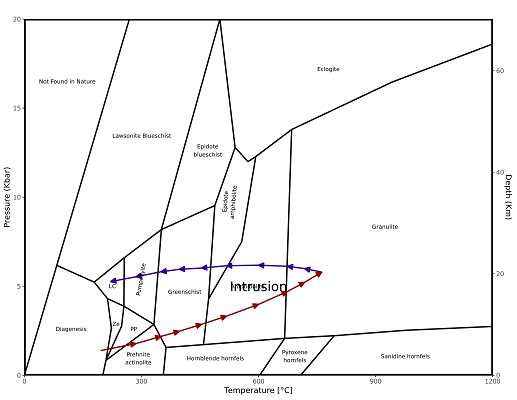

Collision Model

Collision Model pathway

This pathway represents a likely pathway of metamorphism which a rock would experience from the collision of the Earth’s tectonic plates

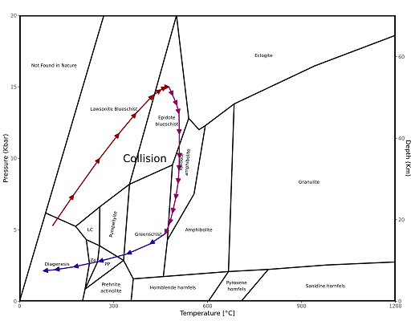

Invert Y axis

Invert Y axis

This feature allows the user to swap the Y axis direction, so that down in the plot parallels down from the Earth’s surface

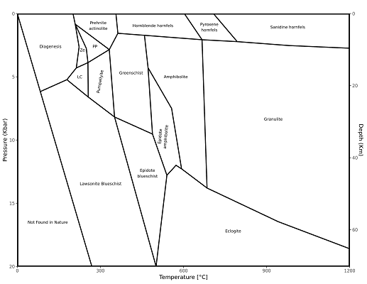

10 degree/km Geothermal Gradient

10 degree/km Geothermal Gradient

This is a simple model of the Earth’s geothermal gradient, where the slope is represented by 10 degrees per kilometer of depth

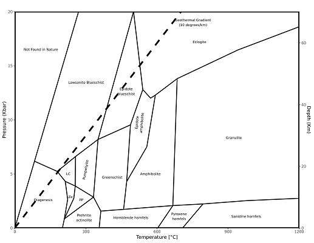

20 degree/km Geothermal Gradient

20 degree/km Geothermal Gradient

This is a simple model of the Earth’s geothermal gradient, where the slope is represented by 20 degrees per kilometer of depth

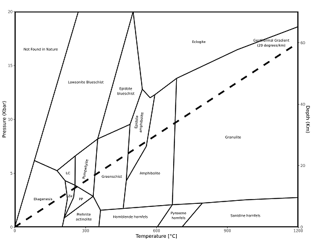

30 degree/km Geothermal Gradient

30 degree/km Geothermal Gradient

This is a simple model of the Earth’s geothermal gradient, where the slope is represented by 30 degrees per kilometer of depth

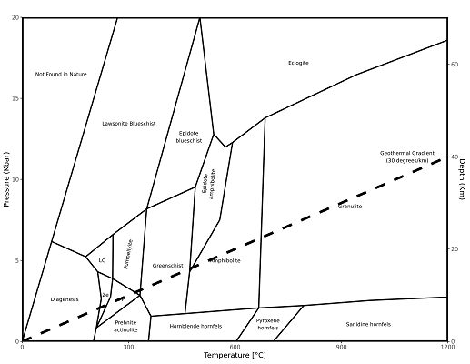

Wet Granite Solidus

Wet Granite Solidus

This curve represents the temperature and pressure conditions of the solidus of wet granite

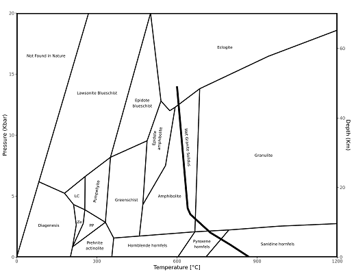

Annite + Quartz + 1/2 O2 and K-Spar + Magnetite + H2O

Annite + Quartz + 1/2 O2 and K-Spar + Magnetite + H2O mineral phase boundary

This curve represents the mineral phase boundary between annite, quartz, and oxygen AND potassium feldspar, magnetite, and water

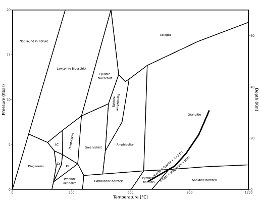

Phlogopite + Quartz and Melt + Orthopyroxene

Phlogopite + Quartz and Melt + Orthopyroxene mineral phase boundary

This curve represents the mineral phase boundary between phlogopite, quartz, and melt AND orthopyroxene

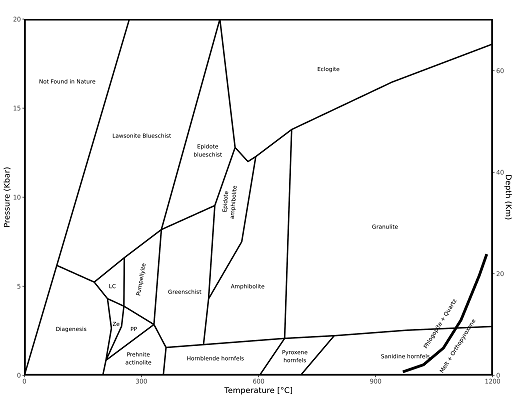

Anhydrous Minimum Melting Temperature

Anhydrous Minimum Melting Temperature

This curve represents the minimum melting temperature for anhydrous minerals with respect to pressure conditions

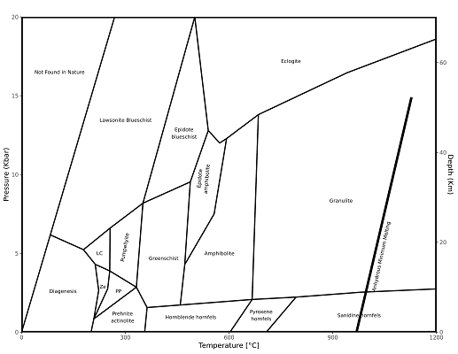

Biotite + Sillimanite and Codierite + K-Spar

Biotite + Sillimanite and Codierite + K-Spar mineral phase boundary

This curve represents the mineral phase boundary between biotite and sillimanite AND cordierite and potassium feldspar

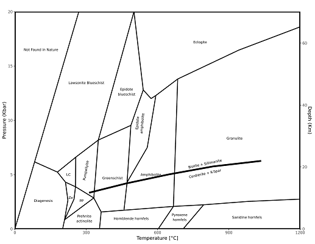

Aragonite and Calcite

Aragonite and Calcite mineral phase boundary

This curve represents the mineral phase boundary between aragonite AND calcite

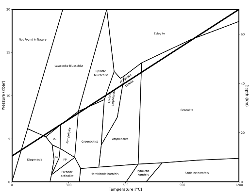

Muscovite + Quartz and Al2SiO5 + KAlSi3O8 + H2O

Muscovite + Quartz and Al2SiO5 + KAlSi3O8 + H2O mineral phase boundary

This curve represents the mineral phase boundary between muscovite and quartz AND aluminosilicates, potassium feldspar, and water

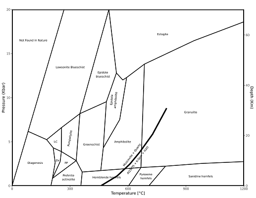